# Patterns of research effort and extinction risk of marine mammals in the Philippines

Likko

September 9, 2020

The following packages are required to run all the codes.

- dplyr
- tidyr
- ggfortify
- rockchalk
- lattice
- car
- MASS
- AICcmodavg
- MuMIn
- ggplot2
- ggpubr
- viridis
- ggridges
- hrbrthemes
- lme4
- GLMMadaptive

#### **Input the dataset into R**

```r
lifehistoryparams<-read.csv("C:/Users/likko/Documents/PH MARMAM papers/lifehistoryparams.csv")
```

To look at a quick summary of the dataset, we use the function summary.

```r
summary(lifehistoryparams)
```

```
 Superfamily           Family            species              values        ageatsex      maxlength
 Length:30          Length:30          Length:30          Min.   : 0.0   Min.   : 2.5   Min.   : 1.5
 Class :character   Class :character   Class :character   1st Qu.: 1.2   1st Qu.: 5.6   1st Qu.: 2.7
 Mode  :character   Mode  :character   Mode  :character   Median : 6.5   Median : 9.0   Median : 3.8
                                                          Mean   : 6.0   Mean   : 8.3   Mean   : 6.8
                                                          3rd Qu.: 9.0   3rd Qu.:10.2   3rd Qu.: 9.1
                                                          Max.   :19.0   Max.   :15.0   Max.   :25.0
                                                                         NA's   :8
 gregariousness   habitat            strandings   redlistPH         redlistglobal           SREA
 Min.   :  1    Length:30          Min.   :  0   Length:30          Length:30          Min.   :0.00
 1st Qu.:  2    Class :character   1st Qu.:  3   Class :character   Class :character   1st Qu.:0.04
 Median :  4    Mode  :character   Median : 15   Mode  :character   Mode  :character   Median :0.22
 Mean   : 24                       Mean   : 29                                         Mean   :0.20
 3rd Qu.: 27                       3rd Qu.: 48                                         3rd Qu.:0.30
 Max.   :143                       Max.   :145                                         Max.   :0.63
 NA's   :6
```

The first few rows of the dataset

```r
head(lifehistoryparams)
```

|  | Superfamily | Family | species | values | ageatsex | maxlength | gregariousness | habitat | strandings | redlistPH | redlistglobal | SREA |
| --- | --- | --- | --- | --- | --- | --- | --- | --- | --- | --- | --- | --- |
| 1 | Dugongidae | Dugongidae | Dugong dugon | 6 | 7.0 | 3.3 | 1 | coastal | 62 | CR | VU | 0.20 |
| 2 | Delphinoidea | Delphinidae | Feresa attenuata | 7 | NA | 2.6 | 3 | offshore | 15 | DD | LC | 0.23 |
| 3 | Delphinoidea | Delphinidae | Globicephala macrorhynchus | 10 | 10.5 | 6.3 | 52 | offshore | 36 | DD | LC | 0.33 |
| 4 | Delphinoidea | Delphinidae | Grampus griseus | 9 | 9.0 | 3.8 | 8 | offshore | 69 | DD | LC | 0.30 |
| 5 | Delphinoidea | Delphinidae | Lagenodelphis hosei | 15 | 6.0 | 2.7 | 92 | offshore | 83 | VU | LC | 0.50 |
| 6 | Delphinoidea | Delphinidae | Orcaella brevirostris | 8 | 4.5 | 2.8 | 4 | coastal | 4 | CR | CR | 0.27 |

Types of variables whether character string, numerical, or categorical

```r
str(lifehistoryparams)
```

```
'data.frame':   30 obs. of  12 variables:
 $ Superfamily   : chr  "Dugongidae" "Delphinoidea" "Delphinoidea" "Delphinoidea" ...
 $ Family        : chr  "Dugongidae" "Delphinidae" "Delphinidae" "Delphinidae" ...
 $ species       : chr  "Dugong dugon" "Feresa attenuata" "Globicephala macrorhynchus" "Grampus griseus" ...
 $ values        : int  6 7 10 9 15 8 1 9 2 11 ...
 $ ageatsex      : num  7 NA 10.5 9 6 4.5 15 14 9.5 10.5 ...
 $ maxlength     : num  3.3 2.6 6.35 3.8 2.7 2.75 9.15 2.78 5.5 2.5 ...
 $ gregariousness: num  1 3 52 8 92 4 3 143 30 84 ...
 $ habitat       : chr  "coastal" "offshore" "offshore" "offshore" ...
 $ strandings    : int  62 15 36 69 83 4 0 60 15 54 ...
 $ redlistPH     : chr  "CR" "DD" "DD" "DD" ...
 $ redlistglobal : chr  "VU" "LC" "LC" "LC" ...
 $ SREA          : num  0.2 0.23 0.33 0.3 0.5 0.27 0.03 0.27 0.07 0.37 ...
```

Calling which columns only to use from the dataframe

```r
cols <- c(4:10)
lhp<-lifehistoryparams[,cols]
str(lhp)
```

```
'data.frame':   30 obs. of  7 variables:
 $ values        : int  6 7 10 9 15 8 1 9 2 11 ...
 $ ageatsex      : num  7 NA 10.5 9 6 4.5 15 14 9.5 10.5 ...
 $ maxlength     : num  3.3 2.6 6.35 3.8 2.7 2.75 9.15 2.78 5.5 2.5 ...
 $ gregariousness: num  1 3 52 8 92 4 3 143 30 84 ...
 $ habitat       : chr  "coastal" "offshore" "offshore" "offshore" ...
 $ strandings    : int  62 15 36 69 83 4 0 60 15 54 ...
 $ redlistPH     : chr  "CR" "DD" "DD" "DD" ...
```

Note: column names cannot have a space!!

Renaming the response variable name from ‘values to ’Research effort’

```r
head(lhp)
```

|  | values | ageatsex | maxlength | gregariousness | habitat | strandings | redlistPH |
| --- | --- | --- | --- | --- | --- | --- | --- |
| 1 | 6 | 7.0 | 3.3 | 1 | coastal | 62 | CR |
| 2 | 7 | NA | 2.6 | 3 | offshore | 15 | DD |
| 3 | 10 | 10.5 | 6.3 | 52 | offshore | 36 | DD |
| 4 | 9 | 9.0 | 3.8 | 8 | offshore | 69 | DD |
| 5 | 15 | 6.0 | 2.7 | 92 | offshore | 83 | VU |
| 6 | 8 | 4.5 | 2.8 | 4 | coastal | 4 | CR |

```r
lhp<-lhp %>% rename(Research.effort = values)
```

Check for missing values

```r
colSums(is.na(lhp))
```

```
Research.effort        ageatsex       maxlength  gregariousness         habitat      strandings
              0               8               0               6               0               0
      redlistPH
              0
```

Check for rows with complete cases

```r
complete.cases(lhp)
```

```
 [1]  TRUE FALSE  TRUE  TRUE  TRUE  TRUE  TRUE  TRUE  TRUE  TRUE FALSE  TRUE FALSE  TRUE  TRUE  TRUE FALSE
[18]  TRUE  TRUE FALSE  TRUE FALSE FALSE FALSE FALSE  TRUE FALSE  TRUE FALSE  TRUE
```

Only retain rows with complete values

```r
lhp2<-na.omit(lhp)
```

Check again if incomplete cases have been successfully removed

```r
complete.cases(lhp2)
```

```
 [1] TRUE TRUE TRUE TRUE TRUE TRUE TRUE TRUE TRUE TRUE TRUE TRUE TRUE TRUE TRUE TRUE TRUE TRUE TRUE
```

Look at variables again

```r
str(lhp2)
```

```
'data.frame':   19 obs. of  7 variables:
 $ Research.effort: int  6 10 9 15 8 1 9 2 11 19 ...
 $ ageatsex       : num  7 10.5 9 6 4.5 15 14 9.5 10.5 5.5 ...
 $ maxlength      : num  3.3 6.35 3.8 2.7 2.75 9.15 2.78 5.5 2.5 2.06 ...
 $ gregariousness : num  1 52 8 92 4 3 143 30 84 90 ...
 $ habitat        : chr  "coastal" "offshore" "offshore" "offshore" ...
 $ strandings     : int  62 36 69 83 4 0 60 15 54 145 ...
 $ redlistPH      : chr  "CR" "DD" "DD" "VU" ...
 - attr(*, "na.action")= 'omit' Named int [1:11] 2 11 13 17 20 22 23 24 25 27 ...
  ..- attr(*, "names")= chr [1:11] "2" "11" "13" "17" ...
```

Check how many values are in each category in the variable ‘habitat’

```r
table(lhp2$habitat)
```

```
 coastal offshore
       5       14
```

Check how many calues are in each category in the variable ‘redlistPH’

```r
table(lhp2$redlistPH)
```

```
         CR          DD notassessed          VU
          2          12           1           4
```

What are the categories in the variable ‘redlistPH’?

```r
levels(lhp2$redlistPH)
```

This gives you a NULL answer because if you check again using the str function, the variable ‘redlistPH’ is a character string and not a categorical variable. we need to change this.

Change ‘redlistPH’ from a character variable into a categorical variable.

```r
lhp2$redlistPH=as.factor(lhp2$redlistPH)
```

Now check again

```r
levels(lhp2$redlistPH)
```

```
[1] "CR"          "DD"          "notassessed" "VU"
```

Collapse DD and notassessed into one level of a factor using combine Levels function in rockchalk package.

```r
lhp2$redlistPH<-combineLevels(lhp2$redlistPH, levs = c("DD","notassessed"), newLabel = "notevaluated")
```

```
The original levels CR DD notassessed VU
have been replaced by CR VU notevaluated
```

## **Data exploration**

Check for outliers in data using cleveland dotplots

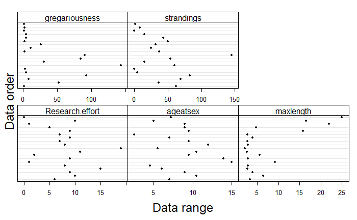

```r
var<-c("Research.effort","ageatsex","maxlength", "gregariousness", "strandings")

dotplot(as.matrix(as.matrix(lhp2[,var])),
        groups=FALSE,
        strip=strip.custom(bg='white',
                           par.strip.text=list(cex=1)),
        scales=list(x=list(relation="free", draw=TRUE),
                    y=list(relation="free",draw=FALSE)),
        col=1, cex=0.5, pch=16,
        xlab=list(label="Data range", cex=1.5),
        ylab=list(label="Data order", cex=1.5))
```

```r
sum(lhp2$values==0)
```

```
[1] 0
```

Cleveland dot plots show potential outliers. If the dots in the graph are further away to the right or left, those may be outliers.

Let’s plot covariates against each other and check collinearity, do not include response variable.

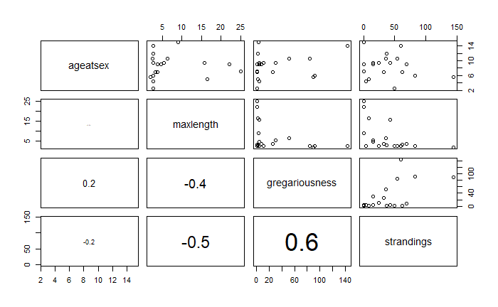

```r
Coll <- c("ageatsex", "maxlength", "gregariousness", "strandings")

#Fig 4.2
panel.cor <- function(x, y, digits=1, prefix="", cex.cor = 6)
{usr <- par("usr"); on.exit(par(usr))
par(usr = c(0, 1, 0, 1))
r1=cor(x,y,use="pairwise.complete.obs")
r <- abs(cor(x, y,use="pairwise.complete.obs"))
txt <- format(c(r1, 0.1), digits=digits)[1]
txt <- paste(prefix, txt, sep="")
if(missing(cex.cor)) { cex <- 0.6/strwidth(txt) } else {
  cex = cex.cor}
text(0.5, 0.5, txt, cex = cex * r)}
pairs(lhp2[, Coll], lower.panel = panel.cor, cex.labels = 1.3)
```

There is a slight correlation between gregariousness and strandings, maxlength and strandings.

Let’s quantify the correlation using variance inflation factor (VIF). vif function is from the car package. so make sure to install car package first.

```r
vif(glm(Research.effort~ageatsex+maxlength+gregariousness+strandings,
        family=poisson,
        data=lhp2))
```

```
      ageatsex      maxlength gregariousness     strandings
           1.5            1.3            2.3            2.5
```

The vif values are all below the threshold of 3 so correlation is not too much.

Now let’s visualize our data by plotting response variable against covariates.

```r
par(mfrow=c(2,3),mar=c(5,5,1,1))
plot(y=lhp2$Research.effort, x=lhp2$ageatsex, xlab="age at sexual", ylab= "number of publications",)
plot(Research.effort~maxlength, data=lhp2, xlab="maxmimum length", ylab="number of publications")
```

```r
plot(Research.effort~gregariousness, data=lhp2, xlab="group sizes", ylab="number of publications")
plot(Research.effort~strandings, data=lhp2,  xlab="number of stranded individuals", ylab="number of publications")
```

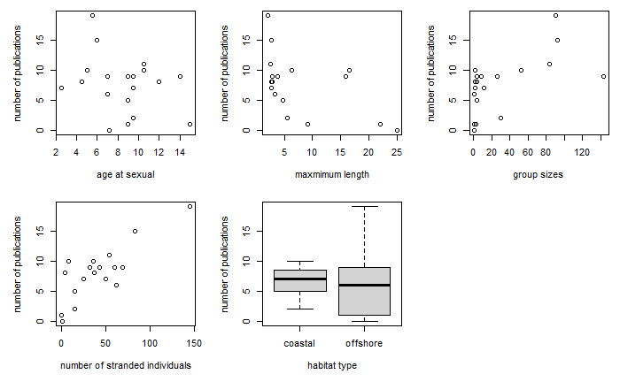

```r
boxplot(values~habitat, data=lifehistoryparams, xlab="habitat type", ylab="number of publications")
```

Let’s try to put regression line on the scatterplot.

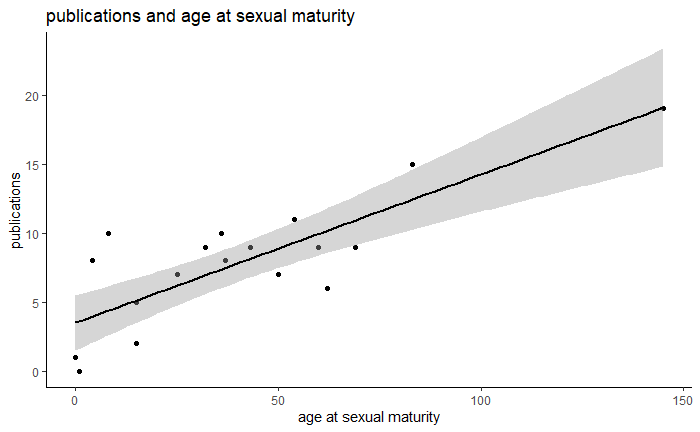

```r
ggplot(lhp2, aes(x=strandings, y=Research.effort)) +
  geom_point()+
  geom_smooth(method=lm, color="black")+
  labs(title="publications and age at sexual maturity",
       x="age at sexual maturity", y = "publications")+
  theme_classic()
```

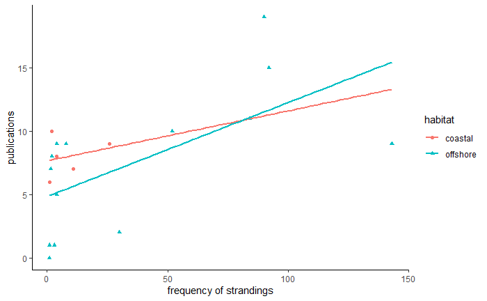

```r
p <- ggplot(lhp2, aes(x=gregariousness, y=Research.effort, color=habitat, shape=habitat)) +
  geom_point()+
  geom_smooth(method=lm, se=FALSE, fullrange=TRUE)+
  labs(x="frequency of strandings", y = "publications")
p + theme_classic()
```

Now that we have thoroughly explored our dataset, we can now proceed to the GLM analysis.

# **Part 1 of analysis**

### **Generalized Linear Model**

Let’s model the response variable with all the exploratory variables.

```r
glm1<-glm(Research.effort~ageatsex+maxlength+gregariousness+habitat+strandings,
          data=lhp2,
          family=poisson(link=log))
summary(glm1)
```

```
Call:
glm(formula = Research.effort ~ ageatsex + maxlength + gregariousness +
    habitat + strandings, family = poisson(link = log), data = lhp2)

Deviance Residuals:
    Min       1Q   Median       3Q      Max
-2.4662  -0.9289  -0.0141   0.5769   1.7851

Coefficients:
                Estimate Std. Error z value Pr(>|z|)
(Intercept)      2.20075    0.35893    6.13  8.7e-10 ***
ageatsex        -0.03537    0.03496   -1.01    0.312
maxlength       -0.02185    0.01888   -1.16    0.247
gregariousness   0.00416    0.00273    1.52    0.128
habitatoffshore -0.29870    0.23086   -1.29    0.196
strandings       0.00699    0.00321    2.18    0.029 *
---
Signif. codes:  0 ‘***’ 0.001 ‘**’ 0.01 ‘*’ 0.05 ‘.’ 0.1 ‘ ’ 1

(Dispersion parameter for poisson family taken to be 1)

    Null deviance: 62.146  on 18  degrees of freedom
Residual deviance: 25.189  on 13  degrees of freedom
AIC: 104.6

Number of Fisher Scoring iterations: 5
```

Using the deviance and residual values from the model, let’s check for overdispersion.

```r
overdispersion<-glm1$deviance/glm1$df.residual
overdispersion
```

```
[1] 1.9
```

The data is overdispersed. Let’s check for interaction with habitat.

```r
glm2<-glm(Research.effort~ageatsex+maxlength+gregariousness*habitat+strandings,
          data=lhp2,
          family=poisson(link=log))
summary(glm2)
```

```
Call:
glm(formula = Research.effort ~ ageatsex + maxlength + gregariousness *
    habitat + strandings, family = poisson(link = log), data = lhp2)

Deviance Residuals:
    Min       1Q   Median       3Q      Max
-2.4652  -0.9296   0.0035   0.5767   1.7867

Coefficients:
                                Estimate Std. Error z value Pr(>|z|)
(Intercept)                     2.204332   0.395673    5.57  2.5e-08 ***
ageatsex                       -0.035352   0.034954   -1.01     0.31
maxlength                      -0.021898   0.018994   -1.15     0.25
gregariousness                  0.003807   0.016589    0.23     0.82
habitatoffshore                -0.302083   0.279372   -1.08     0.28
strandings                      0.006982   0.003222    2.17     0.03 *
gregariousness:habitatoffshore  0.000358   0.016657    0.02     0.98
---
Signif. codes:  0 ‘***’ 0.001 ‘**’ 0.01 ‘*’ 0.05 ‘.’ 0.1 ‘ ’ 1

(Dispersion parameter for poisson family taken to be 1)

    Null deviance: 62.146  on 18  degrees of freedom
Residual deviance: 25.189  on 12  degrees of freedom
AIC: 106.6

Number of Fisher Scoring iterations: 5
```

```r
overdispersion2<-glm2$deviance/glm2$df.residual
overdispersion2
```

```
[1] 2.1
```

It is still overdispersed. Interaction is not a factor. Let’s check for influential outliers.

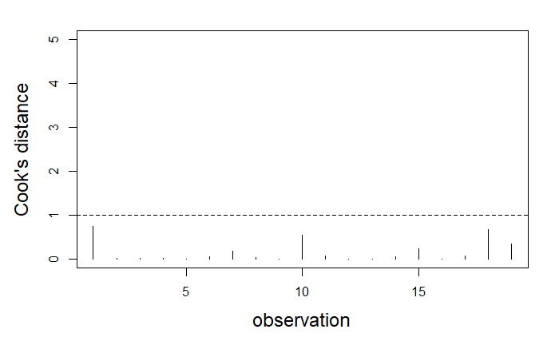

```r
par(mfrow=c(1,1), mar=c(5,5,2,2))
plot(cooks.distance(glm2),
     xlab="observation",
     ylab="Cook's distance",
     type="h",
     ylim=c(0,5),
     cex.lab=1.5)
abline(h=1,lty=2)
```

There are no influential outliers.

Let’ try other link functions (identity)

```r
glm3<-glm(Research.effort~ageatsex+maxlength+gregariousness+habitat+strandings,
          data=lhp2,
          family=poisson(link=identity))
summary(glm3)
```

```
Call:
glm(formula = Research.effort ~ ageatsex + maxlength + gregariousness +
    habitat + strandings, family = poisson(link = identity),
    data = lhp2)

Deviance Residuals:
   Min      1Q  Median      3Q     Max
-2.079  -0.559  -0.193   0.483   1.487

Coefficients:
                Estimate Std. Error z value Pr(>|z|)
(Intercept)       7.1711     2.4853    2.89  0.00391 **
ageatsex         -0.1064     0.2028   -0.52  0.59984
maxlength        -0.0916     0.0822   -1.11  0.26521
gregariousness    0.0199     0.0227    0.88  0.38103
habitatoffshore  -3.4867     1.7528   -1.99  0.04668 *
strandings        0.1045     0.0314    3.33  0.00087 ***
---
Signif. codes:  0 ‘***’ 0.001 ‘**’ 0.01 ‘*’ 0.05 ‘.’ 0.1 ‘ ’ 1

(Dispersion parameter for poisson family taken to be 1)

    Null deviance: 62.146  on 18  degrees of freedom
Residual deviance: 15.221  on 13  degrees of freedom
AIC: 94.59

Number of Fisher Scoring iterations: 14
```

```r
overdispersion3<-glm3$deviance/glm3$df.residual
overdispersion3
```

```
[1] 1.2
```

It still overdispersed.

Let’s try square-root link.

```r
glm4<-glm(Research.effort~ageatsex+maxlength+gregariousness+habitat+strandings,
          data=lhp2,
          family=poisson(link=sqrt))
summary(glm4)
```

```
Call:
glm(formula = Research.effort ~ ageatsex + maxlength + gregariousness +
    habitat + strandings, family = poisson(link = sqrt), data = lhp2)

Deviance Residuals:
   Min      1Q  Median      3Q     Max
-2.038  -0.673  -0.149   0.463   1.675

Coefficients:
                Estimate Std. Error z value Pr(>|z|)
(Intercept)      2.85372    0.49128    5.81  6.3e-09 ***
ageatsex        -0.04021    0.04654   -0.86   0.3876
maxlength       -0.02468    0.02095   -1.18   0.2388
gregariousness   0.00487    0.00389    1.25   0.2103
habitatoffshore -0.52585    0.31926   -1.65   0.0995 .
strandings       0.01468    0.00516    2.84   0.0045 **
---
Signif. codes:  0 ‘***’ 0.001 ‘**’ 0.01 ‘*’ 0.05 ‘.’ 0.1 ‘ ’ 1

(Dispersion parameter for poisson family taken to be 1)

    Null deviance: 62.146  on 18  degrees of freedom
Residual deviance: 20.993  on 13  degrees of freedom
AIC: 100.4

Number of Fisher Scoring iterations: 8
```

```r
overdispersion4<-glm4$deviance/glm4$df.residual
overdispersion4
```

```
[1] 1.6
```

It is still overdispersed.

Let’s check for non-linearity of data using pearson coefficients

#Non-linearity

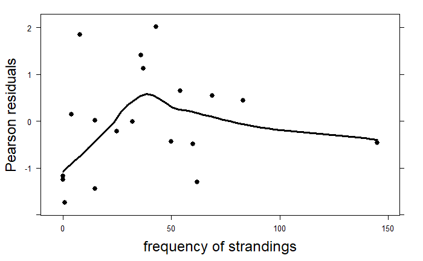

```r
E1 <- resid(glm1, type = "pearson")

#strandings
xyplot(E1 ~ strandings,
       data = lhp2,
       ylab = list("Pearson residuals", cex = 1.5),
       xlab = list("frequency of strandings", cex = 1.5),
       strip = function(bg='white', ...)
         strip.default(bg='white', ...),
       scales = list(alternating = TRUE,
                     x = list(relation = "free"),
                     y = list(relation = "same")),
       panel = function(x,y){
         panel.points(x,y, col = 1, pch = 16, cex = 1.0)
         panel.loess(x,y, col = 1, lwd = 3)})
```

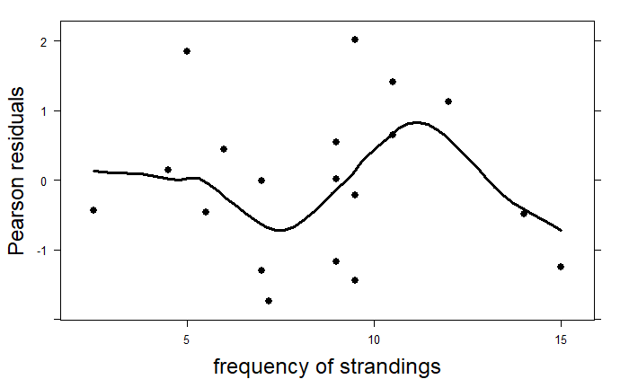

```r
#ageatsex
xyplot(E1 ~ ageatsex,
       data = lhp2,
       ylab = list("Pearson residuals", cex = 1.5),
       xlab = list("frequency of strandings", cex = 1.5),
       strip = function(bg='white', ...)
         strip.default(bg='white', ...),
       scales = list(alternating = TRUE,
                     x = list(relation = "free"),
                     y = list(relation = "same")),
       panel = function(x,y){
         panel.points(x,y, col = 1, pch = 16, cex = 1.0)
         panel.loess(x,y, col = 1, lwd = 3)})
```

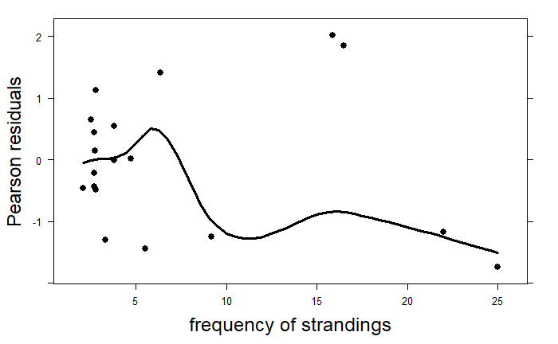

```r
#maxlength
xyplot(E1 ~ maxlength,
       data = lhp2,
       ylab = list("Pearson residuals", cex = 1.5),
       xlab = list("frequency of strandings", cex = 1.5),
       strip = function(bg='white', ...)
         strip.default(bg='white', ...),
       scales = list(alternating = TRUE,
                     x = list(relation = "free"),
                     y = list(relation = "same")),
       panel = function(x,y){
         panel.points(x,y, col = 1, pch = 16, cex = 1.0)
         panel.loess(x,y, col = 1, lwd = 3)})
```

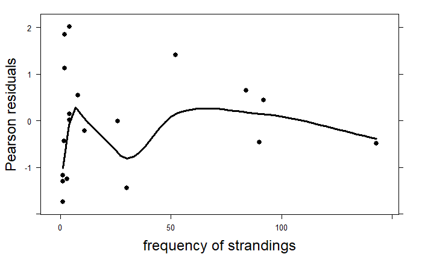

```r
#gregariousness
xyplot(E1 ~ gregariousness,
       data = lhp2,
       ylab = list("Pearson residuals", cex = 1.5),
       xlab = list("frequency of strandings", cex = 1.5),
       strip = function(bg='white', ...)
         strip.default(bg='white', ...),
       scales = list(alternating = TRUE,
                     x = list(relation = "free"),
                     y = list(relation = "same")),
       panel = function(x,y){
         panel.points(x,y, col = 1, pch = 16, cex = 1.0)
         panel.loess(x,y, col = 1, lwd = 3)})
```

There is no evidence of non-linear patterns.

Finally, to account for overdispersion, we need to change the distribution family to negatvie binomial which is used to account for true overdispersion.

```r
nbglm<-glm.nb(Research.effort~ageatsex+maxlength+gregariousness+habitat+strandings,
              data=lhp2)
```

```
iteration limit reachediteration limit reached
```

```r
summary(nbglm)
```

```
Call:
glm.nb(formula = Research.effort ~ ageatsex + maxlength + gregariousness +
    habitat + strandings, data = lhp2, init.theta = 68588.58507,
    link = log)

Deviance Residuals:
    Min       1Q   Median       3Q      Max
-2.4662  -0.9289  -0.0141   0.5769   1.7850

Coefficients:
                Estimate Std. Error z value Pr(>|z|)
(Intercept)      2.20074    0.35896    6.13  8.7e-10 ***
ageatsex        -0.03536    0.03496   -1.01    0.312
maxlength       -0.02185    0.01888   -1.16    0.247
gregariousness   0.00416    0.00273    1.52    0.128
habitatoffshore -0.29871    0.23088   -1.29    0.196
strandings       0.00699    0.00321    2.18    0.029 *
---
Signif. codes:  0 ‘***’ 0.001 ‘**’ 0.01 ‘*’ 0.05 ‘.’ 0.1 ‘ ’ 1

(Dispersion parameter for Negative Binomial(68589) family taken to be 1)

    Null deviance: 62.140  on 18  degrees of freedom
Residual deviance: 25.187  on 13  degrees of freedom
AIC: 106.6

Number of Fisher Scoring iterations: 1

              Theta:  68589
          Std. Err.:  2e+06
Warning while fitting theta: iteration limit reached

 2 x log-likelihood:  -93
```

```r
odsnb <- nbglm$deviance/nbglm$df.residual
odsnb
```

```
[1] 1.9
```

It is still overdispersed. We need to do model fitting.

But first, plot pearson residuals against fitted values

```r
E2 <- resid(nbglm, test='pearson')
F2 <- fitted(nbglm)

par(mfrow = c(2,3), mar = c(5,5,1,1))
plot(x = F2,
     y = E2,
     cex.lab = 1.2,
     xlab = "Fitted values",
     ylab = "Pearson residuals")
abline(h = 0, lty = 2)
```

```r
abline(v = 0, lty = 2)

#Plot residuals against all covariates in the model

plot(x = lhp2$ageatsex,
     y = E2,
     xlab = "age at sexual maturity",
     ylab = "Pearson residuals",
     cex.lab = 1.2,
     type = "p")
```

```r
abline(h = 0, lty = 2)

plot(x = lhp2$maxlength,
     y = E2,
     xlab = "maximum length",
     ylab = "Pearson residuals",
     cex.lab = 1.2,
     type = "p")
```

```r
abline(h = 0, lty = 2)

plot(x = lhp2$gregariousness,
     y = E2,
     xlab = "group size",
     ylab = "Pearson residuals",
     cex.lab = 1.2,
     type = "p")
```

```r
abline(h = 0, lty = 2)

plot(x = lhp2$strandings,
     y = E2,
     xlab = "frequency of strandings",
     ylab = "Pearson residuals",
     cex.lab = 1.2,
     type = "p")
```

```r
abline(h = 0, lty = 2)


plot(x = lhp2$redlistPH,
     y = E2,
     xlab = "red list evaluation",
     ylab = "Pearson residuals",
     cex.lab = 1.2,
     type = "p")
```

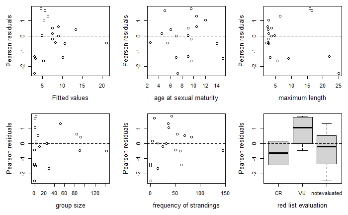

```r
abline(h = 0, lty = 2)
```

Pearson residuals plots show no cause for concern as all fitted values of covariates are distributed along the horizontal axis.

Now we plot cook’s distance to check for influential data points.

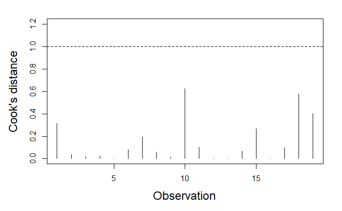

```r
par(mfrow=c(1,1), mar=c(5,5,2,2))
plot(cooks.distance(nbglm),
     xlab = "Observation",
     ylab = "Cook's distance",
     type = "h",
     ylim = c(0, 1.2),
     cex.lab =  1.5)
abline(h = 1, lty = 2)
```

No evidence of influential observations.

Let’s model using above parameters but negative binomial family to account for overdispersion and remove the variable ‘habitat’.

```r
wohabitatnb<-glm.nb(Research.effort~ageatsex+maxlength+gregariousness+strandings,
                    data=lhp2)
```

```
iteration limit reachediteration limit reached
```

```r
summary(wohabitatnb)
```

```
Call:
glm.nb(formula = Research.effort ~ ageatsex + maxlength + gregariousness +
    strandings, data = lhp2, init.theta = 62997.24324, link = log)

Deviance Residuals:
   Min      1Q  Median      3Q     Max
-2.530  -0.955   0.223   0.471   2.098

Coefficients:
               Estimate Std. Error z value Pr(>|z|)
(Intercept)     2.22126    0.35364    6.28  3.4e-10 ***
ageatsex       -0.04877    0.03265   -1.49    0.135
maxlength      -0.02863    0.01803   -1.59    0.112
gregariousness  0.00364    0.00270    1.35    0.178
strandings      0.00559    0.00303    1.85    0.065 .
---
Signif. codes:  0 ‘***’ 0.001 ‘**’ 0.01 ‘*’ 0.05 ‘.’ 0.1 ‘ ’ 1

(Dispersion parameter for Negative Binomial(62997) family taken to be 1)

    Null deviance: 62.140  on 18  degrees of freedom
Residual deviance: 26.851  on 14  degrees of freedom
AIC: 106.2

Number of Fisher Scoring iterations: 1

              Theta:  62997
          Std. Err.:  1850501
Warning while fitting theta: iteration limit reached

 2 x log-likelihood:  -94
```

```r
wohabitatnbods<-wohabitatnb$deviance/wohabitatnb$df.residual
wohabitatnbods  #still overdispersed
```

```
[1] 1.9
```

Now we need to perform model selection. Model selection using the negative binomial model with all parameters a negative binomial accounts for overdispersed data.

```r
stepAIC(wohabitatnb)
```

```
Start:  AIC=104
Research.effort ~ ageatsex + maxlength + gregariousness + strandings

                 Df AIC
- gregariousness  1 104
<none>              104
- ageatsex        1 104
- maxlength       1 105
- strandings      1 106

Step:  AIC=104
Research.effort ~ ageatsex + maxlength + strandings

             Df AIC
- ageatsex    1 103
<none>          104
- maxlength   1 105
- strandings  1 110

Step:  AIC=103
Research.effort ~ maxlength + strandings

             Df AIC
<none>          103
- maxlength   1 104
- strandings  1 110

Call:  glm.nb(formula = Research.effort ~ maxlength + strandings, data = lhp2,
    init.theta = 25161.35086, link = log)

Coefficients:
(Intercept)    maxlength   strandings
    1.79885     -0.03021      0.00899

Degrees of Freedom: 18 Total (i.e. Null);  16 Residual
Null Deviance:      62
Residual Deviance: 30   AIC: 105
```

```r
step(wohabitatnb)
```

```
Start:  AIC=104
Research.effort ~ ageatsex + maxlength + gregariousness + strandings

                 Df Deviance AIC
- gregariousness  1     28.7 104
<none>                  26.9 104
- ageatsex        1     29.1 104
- maxlength       1     29.6 105
- strandings      1     30.2 106

Step:  AIC=104
Research.effort ~ ageatsex + maxlength + strandings

             Df Deviance AIC
- ageatsex    1     29.6 103
<none>              28.7 104
- maxlength   1     32.0 105
- strandings  1     41.4 115

Step:  AIC=103
Research.effort ~ maxlength + strandings

             Df Deviance AIC
<none>              29.6 103
- maxlength   1     32.6 104
- strandings  1     45.2 116

Call:  glm.nb(formula = Research.effort ~ maxlength + strandings, data = lhp2,
    init.theta = 25161.35086, link = log)

Coefficients:
(Intercept)    maxlength   strandings
    1.79885     -0.03021      0.00899

Degrees of Freedom: 18 Total (i.e. Null);  16 Residual
Null Deviance:      62
Residual Deviance: 30   AIC: 105
```

Best fit model contains 2 parameters, max length and strandings.

```r
model<-glm.nb(Research.effort~maxlength+strandings,
              data=lhp2,
              link="log")
summary(model)
```

```
Call:
glm.nb(formula = Research.effort ~ maxlength + strandings, data = lhp2,
    link = "log", init.theta = 25171.23181)

Deviance Residuals:
   Min      1Q  Median      3Q     Max
-2.394  -0.920  -0.172   0.765   2.548

Coefficients:
            Estimate Std. Error z value Pr(>|z|)
(Intercept)  1.79885    0.20147    8.93  < 2e-16 ***
maxlength   -0.03021    0.01819   -1.66    0.097 .
strandings   0.00899    0.00217    4.15  3.4e-05 ***
---
Signif. codes:  0 ‘***’ 0.001 ‘**’ 0.01 ‘*’ 0.05 ‘.’ 0.1 ‘ ’ 1

(Dispersion parameter for Negative Binomial(25171) family taken to be 1)

    Null deviance: 62.130  on 18  degrees of freedom
Residual deviance: 29.572  on 16  degrees of freedom
AIC: 104.9

Number of Fisher Scoring iterations: 1

              Theta:  25171
          Std. Err.:  1241023
Warning while fitting theta: iteration limit reached

 2 x log-likelihood:  -97
```

Single term deletions using the drop1 function

```r
drop1(model, test = "Chi")
```

```
Single term deletions

Model:
Research.effort ~ maxlength + strandings
           Df Deviance AIC   LRT Pr(>Chi)
<none>            29.6 103
maxlength   1     32.6 104  3.02    0.082 .
strandings  1     45.2 116 15.59  7.9e-05 ***
---
Signif. codes:  0 ‘***’ 0.001 ‘**’ 0.01 ‘*’ 0.05 ‘.’ 0.1 ‘ ’ 1
```

```r
drop1(wohabitatnb, test = "Chi")
```

```
Single term deletions

Model:
Research.effort ~ ageatsex + maxlength + gregariousness + strandings
               Df Deviance AIC  LRT Pr(>Chi)
<none>                26.9 104
ageatsex        1     29.1 104 2.23    0.135
maxlength       1     29.6 105 2.73    0.098 .
gregariousness  1     28.7 104 1.81    0.178
strandings      1     30.2 106 3.34    0.067 .
---
Signif. codes:  0 ‘***’ 0.001 ‘**’ 0.01 ‘*’ 0.05 ‘.’ 0.1 ‘ ’ 1
```

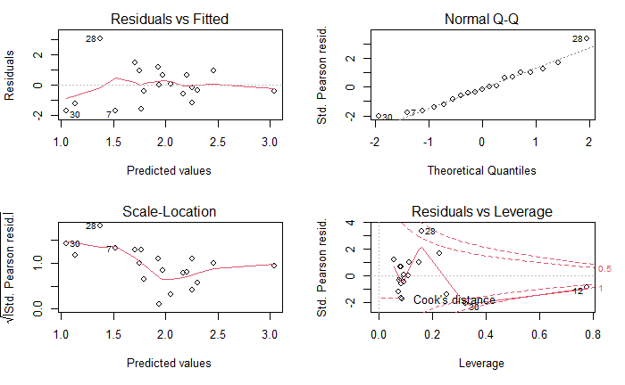

```r
op <- par(mfrow = c(2, 2))
plot(model)
par(op)
```

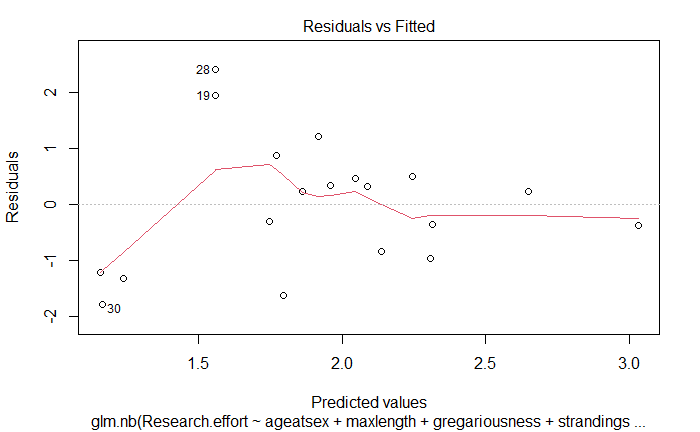

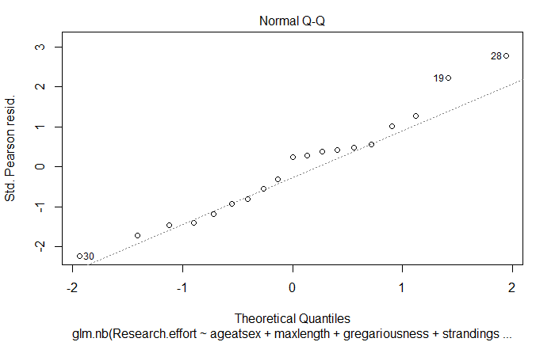

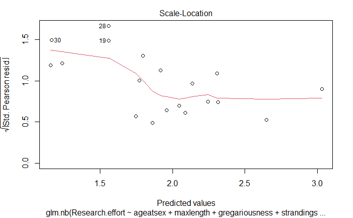

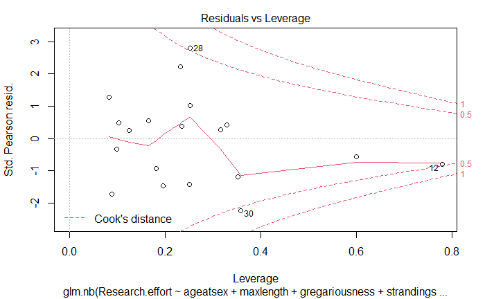

```r
plot(wohabitatnb)
```

Create all models based on stepAIC of wohabitatnb for calculating AIC weights

```r
model1<-glm.nb(Research.effort~ageatsex+maxlength+gregariousness+strandings,
               data=lhp2)
model2<-glm.nb(Research.effort~ageatsex+maxlength+strandings,
               data=lhp2)
model3<-glm.nb(Research.effort~maxlength+strandings,
               data=lhp2)
model4<-glm.nb(Research.effort~strandings,data=lhp2)
```

Comparing the models and model averaging since the difference AIC between models is less than 10, we do model averaging.

The best fit model is listed first.

```r
models <- list(model1, model2, model3, model4)
model.names <- c('model1', 'model2','model3', 'model4')
aictab(cand.set = models, modnames = model.names)
```

```
Model selection based on AICc:

       K AICc Delta_AICc AICcWt Cum.Wt  LL
model4 3  107       0.00   0.48   0.48 -50
model3 4  108       0.37   0.40   0.88 -48
model2 5  111       3.21   0.10   0.97 -48
model1 6  113       5.78   0.03   1.00 -47
```

Now, let’s do model averaging using MuMIn package.

```r
options(na.action = "na.fail") ##  prevent fitting models to different datasets to prevent error on removing NAs in the dataset
#above code line is required for dredge to run

fits <- dredge(model1)
```

```
Fixed term is "(Intercept)"
```

```r
options(digits = 2)
model.sel(fits)
```

```
Global model call: glm.nb(formula = Research.effort ~ ageatsex + maxlength + gregariousness +
    strandings, data = lhp2, init.theta = 62997.24324, link = log)
---
Model selection table
   (Intrc)  agtsx  grgrs  mxlng  strnd df logLik AICc delta weight
9      1.5                      0.0112  3    -50  107  0.00  0.308
13     1.8               -0.030 0.0090  4    -48  108  0.37  0.257
11     1.5        0.0022        0.0094  4    -50  110  2.46  0.090
10     1.7 -0.025               0.0107  4    -50  110  2.62  0.083
14     2.1 -0.027        -0.031 0.0083  5    -48  111  3.21  0.062
15     1.8        0.0016 -0.028 0.0081  5    -48  111  3.63  0.050
12     2.0 -0.048 0.0042        0.0070  5    -48  112  4.13  0.039
8      2.7 -0.080 0.0069 -0.037         5    -49  112  4.73  0.029
4      2.4 -0.089 0.0090                4    -51  113  5.68  0.018
16     2.2 -0.049 0.0036 -0.029 0.0056  6    -47  113  5.78  0.017
5      2.4               -0.063         3    -53  114  6.05  0.015
7      2.1        0.0051 -0.046         4    -52  114  6.46  0.012
6      2.9 -0.060        -0.062         4    -52  115  7.14  0.009
3      1.8        0.0078                3    -54  115  7.42  0.008
1      2.0                              2    -56  117 10.01  0.002
2      2.5 -0.060                       3    -56  119 11.45  0.001
Models ranked by AICc(x)
```

```r
options(na.action = "na.omit") # set back to default
#above code sets back default
```

Check how many models there are.

```r
nrow(fits)
```

```
[1] 16
```

Now let’s look at the summary of the models.

```r
summary(model.avg(fits, subset = delta <= 2))
```

```
Call:
model.avg(object = fits, subset = delta <= 2)

Component model call:
glm.nb(formula = Research.effort ~ <2 unique rhs>, data = lhp2, init.theta = 62997.24324, link =
     log)

Component models:
   df logLik AICc delta weight
2   3    -50  107  0.00   0.55
12  4    -48  108  0.37   0.45

Term codes:
 maxlength strandings
         1          2

Model-averaged coefficients:
(full average)
            Estimate Std. Error Adjusted SE z value Pr(>|z|)
(Intercept)  1.64308    0.22421     0.23505    6.99   <2e-16 ***
strandings   0.01021    0.00244     0.00259    3.94   <2e-16 ***
maxlength   -0.01373    0.01941     0.02005    0.68     0.49

(conditional average)
            Estimate Std. Error Adjusted SE z value Pr(>|z|)
(Intercept)  1.64308    0.22421     0.23505    6.99   <2e-16 ***
strandings   0.01021    0.00244     0.00259    3.94   <2e-16 ***
maxlength   -0.03021    0.01819     0.01967    1.54     0.12
---
Signif. codes:  0 ‘***’ 0.001 ‘**’ 0.01 ‘*’ 0.05 ‘.’ 0.1 ‘ ’ 1
```

```r
summary(model.avg(fits))
```

[output not shown]

Now that we have successfully performed GLM, let’s proceed to the next.

To check for interaction of habitat and gregariousness and effect on publication rate

```r
int1<-glm.nb(Research.effort~gregariousness*habitat, data=lhp2)
summary(int1)
```

```
Call:
glm.nb(formula = Research.effort ~ gregariousness * habitat,
    data = lhp2, init.theta = 6.694399454, link = log)

Deviance Residuals:
    Min       1Q   Median       3Q      Max
-2.7160  -0.9276   0.0455   0.5969   1.1735

Coefficients:
                               Estimate Std. Error z value Pr(>|z|)
(Intercept)                     2.03663    0.32453    6.28  3.5e-10 ***
gregariousness                  0.00475    0.02499    0.19     0.85
habitatoffshore                -0.45287    0.38103   -1.19     0.23
gregariousness:habitatoffshore  0.00472    0.02516    0.19     0.85
---
Signif. codes:  0 ‘***’ 0.001 ‘**’ 0.01 ‘*’ 0.05 ‘.’ 0.1 ‘ ’ 1

(Dispersion parameter for Negative Binomial(6.7) family taken to be 1)

    Null deviance: 33.774  on 18  degrees of freedom
Residual deviance: 24.367  on 15  degrees of freedom
AIC: 115.4

Number of Fisher Scoring iterations: 1

              Theta:  6.69
          Std. Err.:  4.92

 2 x log-likelihood:  -105.43
```

```r
stepAIC(int1)
```

[output not shown]

No interaction whatsoever.

We assume now that the model is ok and we can visualise the results.

```r
#Fig for strandings nbglm

range(lhp2$strandings) #0 - 145
```

```
[1]   0 145
```

```r
MyData <- expand.grid(
  ageatsex  = mean(lhp2$ageatsex),
  maxlength = mean(lhp2$maxlength),
  gregariousness   = mean(lhp2$gregariousness),
  strandings  = seq(0, 150, length = 150))

head(MyData)
```

|  | ageatsex | maxlength | gregariousness | strandings |
| --- | --- | --- | --- | --- |
| 1 | 8.5 | 7.2 | 29 | 0 |
| 2 | 8.5 | 7.2 | 29 | 1 |
| 3 | 8.5 | 7.2 | 29 | 2 |
| 4 | 8.5 | 7.2 | 29 | 3 |
| 5 | 8.5 | 7.2 | 29 | 4 |
| 6 | 8.5 | 7.2 | 29 | 5 |

```r
X <- model.matrix(~ ageatsex + maxlength + gregariousness + strandings, data = MyData)
head(MyData)
```

|  | ageatsex | maxlength | gregariousness | strandings |
| --- | --- | --- | --- | --- |
| 1 | 8.5 | 7.2 | 29 | 0 |
| 2 | 8.5 | 7.2 | 29 | 1 |
| 3 | 8.5 | 7.2 | 29 | 2 |
| 4 | 8.5 | 7.2 | 29 | 3 |
| 5 | 8.5 | 7.2 | 29 | 4 |
| 6 | 8.5 | 7.2 | 29 | 5 |

```r
MyData$eta  <- X %*% coef(model1)
MyData$Pred <- exp(X %*% coef(model1))

#Calculate standard errors (SE) for predicted values
MyData$SE <- sqrt(  diag(X %*% vcov(model1) %*% t(X))  )

#And using the Pred and SE values, calculate 95% confidence intervals
MyData$SeUp <- exp(MyData$eta + 1.96 * MyData$SE)
MyData$SeLo <- exp(MyData$eta - 1.96 * MyData$SE)
head(MyData)
```

|  | ageatsex | maxlength | gregariousness | strandings | eta | Pred | SE | SeUp | SeLo |
| --- | --- | --- | --- | --- | --- | --- | --- | --- | --- |
| 1 | 8.5 | 7.2 | 29 | 0 | 1.7 | 5.5 | 0.15 | 7.5 | 4.1 |
| 2 | 8.5 | 7.2 | 29 | 1 | 1.7 | 5.5 | 0.15 | 7.5 | 4.1 |
| 3 | 8.5 | 7.2 | 29 | 2 | 1.7 | 5.6 | 0.15 | 7.5 | 4.2 |
| 4 | 8.5 | 7.2 | 29 | 3 | 1.7 | 5.6 | 0.15 | 7.5 | 4.2 |
| 5 | 8.5 | 7.2 | 29 | 4 | 1.7 | 5.6 | 0.15 | 7.5 | 4.2 |
| 6 | 8.5 | 7.2 | 29 | 5 | 1.7 | 5.7 | 0.14 | 7.5 | 4.3 |

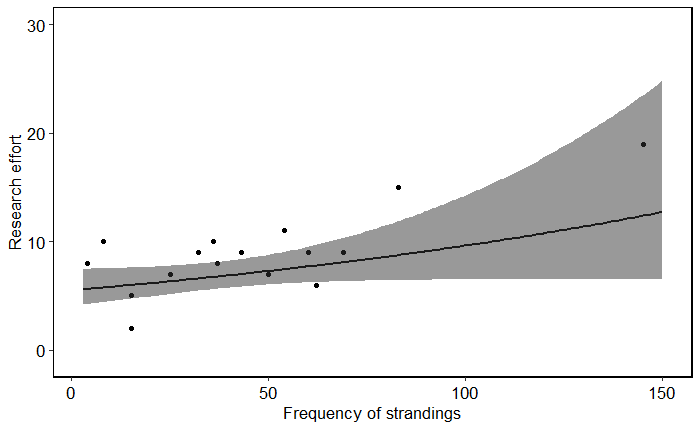

```r
#And plot the observed data, fitted values and 95% CIs of the mean.
p <- ggplot()
p <- p + geom_point(data = lhp2, aes(y = Research.effort, x = strandings),shape = 16,size = 1.5)
p <- p + ylab("Research effort")
p <- p + xlab(expression(paste("Frequency of strandings")))
p <- p + ylim(-1,30)
p <- p + xlim(2.6,150)
p <- p + theme(text = element_text(size=13))
p <- p + theme(panel.background = element_blank())
p <- p + theme(panel.border = element_rect(fill = NA, colour = "black", size = 1))
p <- p + theme(strip.background = element_rect(fill = "white", color = "white", size = 1))
p <- p + geom_line(data = MyData,aes(x = strandings, y = Pred), colour = "black", size = 1)
p <- p + geom_ribbon(data = MyData, aes(x = strandings, ymax = SeUp, ymin = SeLo ), alpha = 0.5)
p
```

```r
#GOODFIGURE!!!!!!##


##############################
#####################################################
#Figure for nbglm. for gregariousness


range(lhp2$gregariousness) #1 - 150
```

```
[1]   1 143
```

```r
MyDatagreg <- expand.grid(
  ageatsex  = mean(lhp2$ageatsex),
  maxlength = mean(lhp2$maxlength),
  strandings   = mean(lhp2$strandings),
  gregariousness  = seq(1, 150, length = 150))
head(MyDatagreg)
```

|  | ageatsex | maxlength | strandings | gregariousness |
| --- | --- | --- | --- | --- |
| 1 | 8.5 | 7.2 | 39 | 1 |
| 2 | 8.5 | 7.2 | 39 | 2 |
| 3 | 8.5 | 7.2 | 39 | 3 |
| 4 | 8.5 | 7.2 | 39 | 4 |
| 5 | 8.5 | 7.2 | 39 | 5 |
| 6 | 8.5 | 7.2 | 39 | 6 |

```r
X2 <- model.matrix(~ ageatsex + maxlength + strandings + gregariousness, data = MyDatagreg)
head(MyDatagreg)
```

|  | ageatsex | maxlength | strandings | gregariousness |
| --- | --- | --- | --- | --- |
| 1 | 8.5 | 7.2 | 39 | 1 |
| 2 | 8.5 | 7.2 | 39 | 2 |
| 3 | 8.5 | 7.2 | 39 | 3 |
| 4 | 8.5 | 7.2 | 39 | 4 |
| 5 | 8.5 | 7.2 | 39 | 5 |
| 6 | 8.5 | 7.2 | 39 | 6 |

```r
MyDatagreg$eta  <- X2 %*% coef(model1)
MyDatagreg$Pred <- exp(X2 %*% coef(model1))

#Calculate standard errors (SE) for predicted values
MyDatagreg$SE <- sqrt(  diag(X2 %*% vcov(model1) %*% t(X2))  )

#And using the Pred and SE values, calculate 95% confidence intervals
MyDatagreg$SeUp <- exp(MyDatagreg$eta + 1.96 * MyDatagreg$SE)
MyDatagreg$SeLo <- exp(MyDatagreg$eta - 1.96 * MyDatagreg$SE)
head(MyDatagreg)
```

|  | ageatsex | maxlength | strandings | gregariousness | eta | Pred | SE | SeUp | SeLo |
| --- | --- | --- | --- | --- | --- | --- | --- | --- | --- |
| 1 | 8.5 | 7.2 | 39 | 1 | 1.7 | 5.7 | 0.17 | 7.9 | 4.1 |
| 2 | 8.5 | 7.2 | 39 | 2 | 1.8 | 5.8 | 0.16 | 7.9 | 4.2 |
| 3 | 8.5 | 7.2 | 39 | 3 | 1.8 | 5.8 | 0.16 | 7.9 | 4.2 |
| 4 | 8.5 | 7.2 | 39 | 4 | 1.8 | 5.8 | 0.16 | 7.9 | 4.3 |
| 5 | 8.5 | 7.2 | 39 | 5 | 1.8 | 5.9 | 0.16 | 7.9 | 4.3 |
| 6 | 8.5 | 7.2 | 39 | 6 | 1.8 | 5.9 | 0.15 | 7.9 | 4.4 |

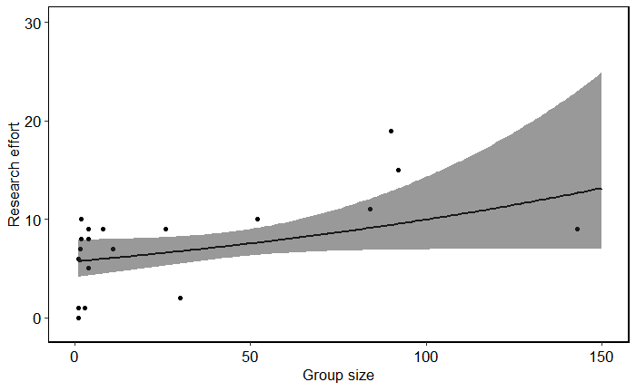

```r
#And plot the observed data, fitted values and 95% CIs of the mean.
pgreg <- ggplot()
pgreg <- pgreg + geom_point(data =lhp2, aes(y = Research.effort, x = gregariousness),shape = 16,size = 1.5)
pgreg <- pgreg + ylab("Research effort")
pgreg <- pgreg + xlab(expression(paste("Group size")))
pgreg <- pgreg + ylim(-1,30)
pgreg <- pgreg + xlim(0,150)
pgreg <- pgreg + theme(text = element_text(size=13))
pgreg <- pgreg + theme(panel.background = element_blank())
pgreg <- pgreg + theme(panel.border = element_rect(fill = NA, colour = "black", size = 1))
pgreg <- pgreg + theme(strip.background = element_rect(fill = "white", color = "white", size = 1))
pgreg <- pgreg + geom_line(data = MyDatagreg,aes(x = gregariousness, y = Pred), colour = "black", size = 1)
pgreg <- pgreg + geom_ribbon(data = MyDatagreg, aes(x = gregariousness, ymax = SeUp, ymin = SeLo ), alpha = 0.5)
pgreg
```

```r
##############################
#Fig for ageatsex

range(lhp2$ageatsex) #2.5 - 15
```

```
[1]  2.5 15.0
```

```r
MyDataage <- expand.grid(
  maxlength  = mean(lhp2$maxlength),
  gregariousness = mean(lhp2$gregariousness),
  strandings   = mean(lhp2$strandings),
  ageatsex  = seq(2.5, 15, length = 15))
head(MyDataage)
```

|  | maxlength | gregariousness | strandings | ageatsex |
| --- | --- | --- | --- | --- |
| 1 | 7.2 | 29 | 39 | 2.5 |
| 2 | 7.2 | 29 | 39 | 3.4 |
| 3 | 7.2 | 29 | 39 | 4.3 |
| 4 | 7.2 | 29 | 39 | 5.2 |
| 5 | 7.2 | 29 | 39 | 6.1 |
| 6 | 7.2 | 29 | 39 | 7.0 |

```r
X3 <- model.matrix(~ maxlength + gregariousness + strandings + ageatsex, data = MyDataage)
head(MyDataage)
```

|  | maxlength | gregariousness | strandings | ageatsex |
| --- | --- | --- | --- | --- |
| 1 | 7.2 | 29 | 39 | 2.5 |
| 2 | 7.2 | 29 | 39 | 3.4 |
| 3 | 7.2 | 29 | 39 | 4.3 |
| 4 | 7.2 | 29 | 39 | 5.2 |
| 5 | 7.2 | 29 | 39 | 6.1 |
| 6 | 7.2 | 29 | 39 | 7.0 |

```r
MyDataage$eta  <- X3 %*% coef(model1)
MyDataage$Pred <- exp(X3 %*% coef(model1))

#Calculate standard errors (SE) for predicted values
MyDataage$SE <- sqrt(  diag(X3 %*% vcov(model1) %*% t(X3))  )

#And using the Pred and SE values, calculate 95% confidence intervals
MyDataage$SeUp <- exp(MyDataage$eta + 1.96 * MyDataage$SE)
MyDataage$SeLo <- exp(MyDataage$eta - 1.96 * MyDataage$SE)
head(MyDataage)
```

|  | maxlength | gregariousness | strandings | ageatsex | eta | Pred | SE | SeUp | SeLo |
| --- | --- | --- | --- | --- | --- | --- | --- | --- | --- |
| 1 | 7.2 | 29 | 39 | 2.5 | 1.2 | 3.3 | 0.44 | 7.7 | 1.4 |
| 2 | 7.2 | 29 | 39 | 3.4 | 1.2 | 3.3 | 0.43 | 7.7 | 1.4 |
| 3 | 7.2 | 29 | 39 | 4.3 | 1.2 | 3.3 | 0.43 | 7.7 | 1.4 |
| 4 | 7.2 | 29 | 39 | 5.2 | 1.2 | 3.3 | 0.43 | 7.8 | 1.4 |
| 5 | 7.2 | 29 | 39 | 6.1 | 1.2 | 3.3 | 0.43 | 7.8 | 1.4 |
| 6 | 7.2 | 29 | 39 | 7.0 | 1.2 | 3.3 | 0.43 | 7.8 | 1.4 |

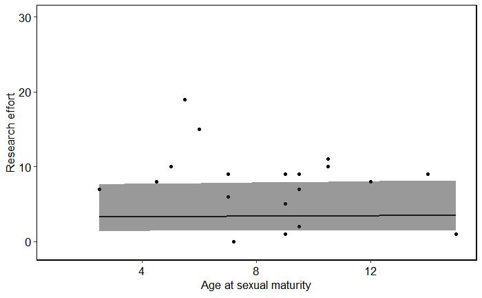

```r
#And plot the observed data, fitted values and 95% CIs of the mean.
page <- ggplot()
page <- page + geom_point(data = lhp2, aes(y = Research.effort, x = ageatsex),shape = 16,size = 1.5)
page <- page + ylab("Research effort")
page <- page + xlab(expression(paste("Age at sexual maturity")))
page <- page + ylim(-1,30)
page <- page + xlim(1,15)
page <- page + theme(text = element_text(size=13))
page <- page + theme(panel.background = element_blank())
page <- page + theme(panel.border = element_rect(fill = NA, colour = "black", size = 1))
page <- page + theme(strip.background = element_rect(fill = "white", color = "white", size = 1))
page <- page + geom_line(data = MyDataage,aes(x = ageatsex, y = Pred), colour = "black", size = 1)
page <- page + geom_ribbon(data = MyDataage, aes(x = ageatsex, ymax = SeUp, ymin = SeLo ), alpha = 0.5)
page
```

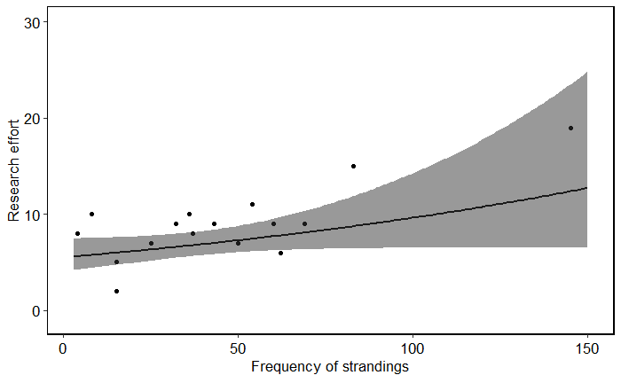

```r
p
```

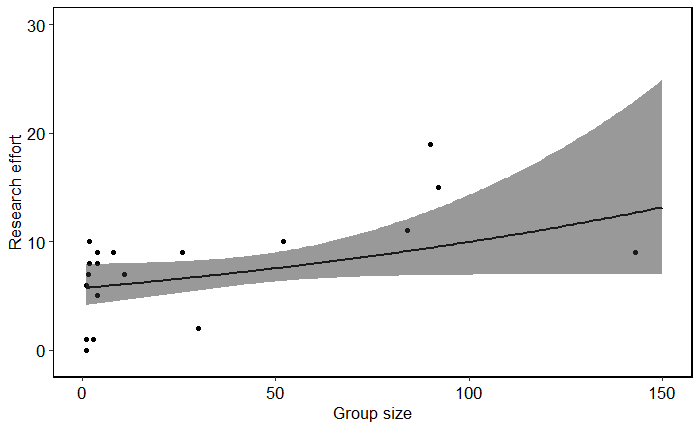

```r
pgreg
```

```r
##############################################################################
#Fig for maximum length


range(lhp2$maxlength) #2.1 - 25
```

```
[1]  2.1 25.0
```

```r
MyDatal <- expand.grid(
  ageatsex  = mean(lhp2$ageatsex),
  gregariousness = mean(lhp2$gregariousness),
  strandings   = mean(lhp2$strandings),
  maxlength  = seq(2.1, 25, length = 25))
head(MyDatal)
```

|  | ageatsex | gregariousness | strandings | maxlength |
| --- | --- | --- | --- | --- |
| 1 | 8.5 | 29 | 39 | 2.1 |
| 2 | 8.5 | 29 | 39 | 3.1 |
| 3 | 8.5 | 29 | 39 | 4.0 |
| 4 | 8.5 | 29 | 39 | 5.0 |
| 5 | 8.5 | 29 | 39 | 5.9 |
| 6 | 8.5 | 29 | 39 | 6.9 |

```r
X4 <- model.matrix(~ ageatsex + gregariousness + strandings + maxlength, data = MyDatal)
head(MyDatal)
```

|  | ageatsex | gregariousness | strandings | maxlength |
| --- | --- | --- | --- | --- |
| 1 | 8.5 | 29 | 39 | 2.1 |
| 2 | 8.5 | 29 | 39 | 3.1 |
| 3 | 8.5 | 29 | 39 | 4.0 |
| 4 | 8.5 | 29 | 39 | 5.0 |
| 5 | 8.5 | 29 | 39 | 5.9 |
| 6 | 8.5 | 29 | 39 | 6.9 |

```r
MyDatal$eta  <- X4 %*% coef(model1)
MyDatal$Pred <- exp(X4 %*% coef(model1))

#Calculate standard errors (SE) for predicted values
MyDatal$SE <- sqrt(  diag(X4 %*% vcov(model1) %*% t(X4))  )

#And using the Pred and SE values, calculate 95% confidence intervals
MyDatal$SeUp <- exp(MyDatal$eta + 1.96 * MyDatal$SE)
MyDatal$SeLo <- exp(MyDatal$eta - 1.96 * MyDatal$SE)
head(MyDatal)
```

|  | ageatsex | gregariousness | strandings | maxlength | eta | Pred | SE | SeUp | SeLo |
| --- | --- | --- | --- | --- | --- | --- | --- | --- | --- |
| 1 | 8.5 | 29 | 39 | 2.1 | 1.1 | 3.0 | 0.43 | 7.0 | 1.3 |
| 2 | 8.5 | 29 | 39 | 3.1 | 1.1 | 3.1 | 0.43 | 7.1 | 1.3 |
| 3 | 8.5 | 29 | 39 | 4.0 | 1.1 | 3.1 | 0.43 | 7.1 | 1.3 |
| 4 | 8.5 | 29 | 39 | 5.0 | 1.1 | 3.1 | 0.43 | 7.1 | 1.3 |
| 5 | 8.5 | 29 | 39 | 5.9 | 1.1 | 3.1 | 0.43 | 7.2 | 1.4 |
| 6 | 8.5 | 29 | 39 | 6.9 | 1.1 | 3.1 | 0.43 | 7.2 | 1.4 |

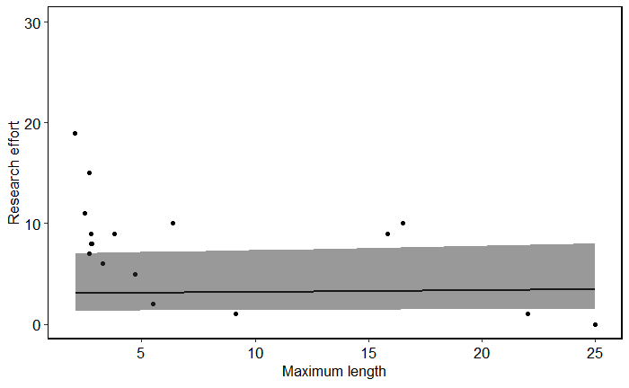

```r
#And plot the observed data, fitted values and 95% CIs of the mean.
pl <- ggplot()
pl <- pl + geom_point(data = lhp2, aes(y =Research.effort, x = maxlength),shape = 16,size = 1.5)
pl <- pl + ylab("Research effort")
pl <- pl + xlab(expression(paste("Maximum length")))
pl <- pl + ylim(0,30)
pl <- pl + xlim(2,25)
pl <- pl + theme(text = element_text(size=13))
pl <- pl + theme(panel.background = element_blank())
pl <- pl + theme(panel.border = element_rect(fill = NA, colour = "black", size = 1))
pl <- pl + theme(strip.background = element_rect(fill = "white", color = "white", size = 1))
pl <- pl + geom_line(data = MyDatal,aes(x = maxlength, y = Pred), colour = "black", size = 1)
pl <- pl + geom_ribbon(data = MyDatal, aes(x = maxlength, ymax = SeUp, ymin = SeLo),alpha = 0.5)

pl
```

```r
#combine all 4 figure into one graph using ggpubr package
theme_set(theme_pubr())

figure <- ggarrange(page, pl, pgreg, p,
                    labels = c("A", "B", "C", "D"),
                    ncol = 2, nrow = 2)
```

```
Removed 3 rows containing missing values (geom_point).Removed 3 row(s) containing missing values (geom_path).
```

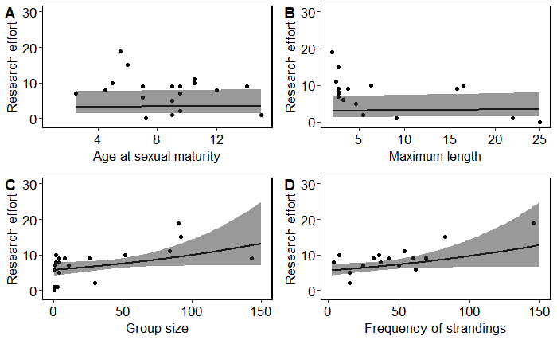

```r
figure
```

#### 1st part of analysis done!

# **Part 2 of analysis**

### **Generalized Linear Mixed Effects Model**

#### *Red List evaluation analysis*

Set up the data format. convert redlist into binary data

```r
str(lifehistoryparams)
```

```
'data.frame':   30 obs. of  12 variables:
 $ Superfamily   : chr  "Dugongidae" "Delphinoidea" "Delphinoidea" "Delphinoidea" ...
 $ Family        : chr  "Dugongidae" "Delphinidae" "Delphinidae" "Delphinidae" ...
 $ species       : chr  "Dugong dugon" "Feresa attenuata" "Globicephala macrorhynchus" "Grampus griseus" ...
 $ values        : int  6 7 10 9 15 8 1 9 2 11 ...
 $ ageatsex      : num  7 NA 10.5 9 6 4.5 15 14 9.5 10.5 ...
 $ maxlength     : num  3.3 2.6 6.35 3.8 2.7 2.75 9.15 2.78 5.5 2.5 ...
 $ gregariousness: num  1 3 52 8 92 4 3 143 30 84 ...
 $ habitat       : chr  "coastal" "offshore" "offshore" "offshore" ...
 $ strandings    : int  62 15 36 69 83 4 0 60 15 54 ...
 $ redlistPH     : chr  "CR" "DD" "DD" "DD" ...
 $ redlistglobal : chr  "VU" "LC" "LC" "LC" ...
 $ SREA          : num  0.2 0.23 0.33 0.3 0.5 0.27 0.03 0.27 0.07 0.37 ...
```

Calling which columns only to use from the dataframe.

```r
cols <- c(1:10)
lhp<-lifehistoryparams[,cols]
str(lhp)
```

```
'data.frame':   30 obs. of  10 variables:
 $ Superfamily   : chr  "Dugongidae" "Delphinoidea" "Delphinoidea" "Delphinoidea" ...
 $ Family        : chr  "Dugongidae" "Delphinidae" "Delphinidae" "Delphinidae" ...
 $ species       : chr  "Dugong dugon" "Feresa attenuata" "Globicephala macrorhynchus" "Grampus griseus" ...
 $ values        : int  6 7 10 9 15 8 1 9 2 11 ...
 $ ageatsex      : num  7 NA 10.5 9 6 4.5 15 14 9.5 10.5 ...
 $ maxlength     : num  3.3 2.6 6.35 3.8 2.7 2.75 9.15 2.78 5.5 2.5 ...
 $ gregariousness: num  1 3 52 8 92 4 3 143 30 84 ...
 $ habitat       : chr  "coastal" "offshore" "offshore" "offshore" ...
 $ strandings    : int  62 15 36 69 83 4 0 60 15 54 ...
 $ redlistPH     : chr  "CR" "DD" "DD" "DD" ...
```

Check for missing values

```r
colSums(is.na(lhp))
```

```
   Superfamily         Family        species         values       ageatsex      maxlength gregariousness
             0              0              0              0              8              0              6
       habitat     strandings      redlistPH
             0              0              0
```

```r
complete.cases(lhp)
```

```
 [1]  TRUE FALSE  TRUE  TRUE  TRUE  TRUE  TRUE  TRUE  TRUE  TRUE FALSE  TRUE FALSE  TRUE  TRUE  TRUE FALSE
[18]  TRUE  TRUE FALSE  TRUE FALSE FALSE FALSE FALSE  TRUE FALSE  TRUE FALSE  TRUE
```

Collapse DD and notassessed into one level of a factor using combine Levels function in rockchalk package

```r
lhp$redlistPH=as.factor(lhp$redlistPH)
lhp$redlistPH<-combineLevels(lhp$redlistPH, levs = c("DD","notassessed"),
                             newLabel = "notevaluated")
```

```
The original levels CR DD notassessed VU
have been replaced by CR VU notevaluated
```

```r
lhp$redlistPH<-combineLevels(lhp$redlistPH, levs = c("CR","VU"), newLabel = "evaluated")
```

```
The original levels CR VU notevaluated
have been replaced by notevaluated evaluated
```

```r
levels(lhp$redlistPH)
```

```
[1] "notevaluated" "evaluated"
```

Try different types of plot to visualize the data

scatter plot

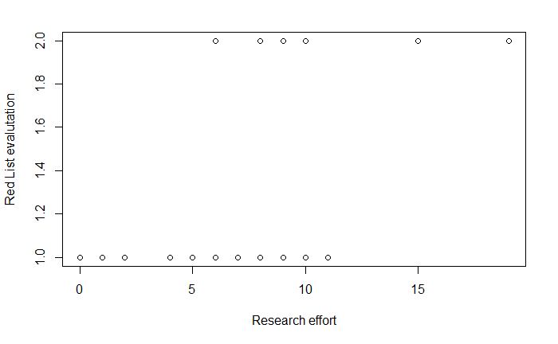

```r
plot(y=lhp$redlistPH, x=lhp$values, xlab="Research effort", ylab="Red List evalutation")
```

not very informative.

Kernel density plot

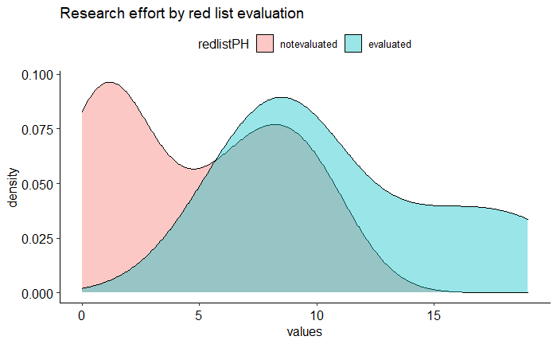

```r
ggplot(lhp,
       aes(x = values,
           fill = redlistPH, xlab="Number of publications")) +
  geom_density(alpha = 0.4) +
  labs(title = "Research effort by red list evaluation")
```

looks okay.

How about a boxplot.

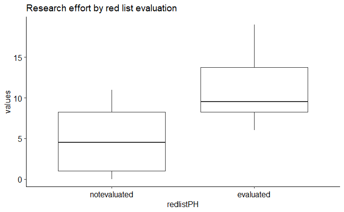

```r
ggplot(lhp,
       aes(x = redlistPH,
           y = values)) +
  geom_boxplot() +
  labs(title = "Research effort by red list evaluation")
```

Nice figure! informative.

Let’s see it as a violing plot superimposed boxplot. Kind of like combining the density plot and boxplot together.

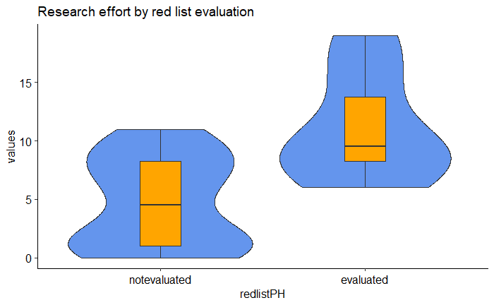

```r
ggplot(lhp,
       aes(x = redlistPH,
           y = values)) +
  geom_violin(fill = "cornflowerblue") +
  geom_boxplot(width = .2,
               fill = "orange",
               outlier.color = "orange",
               outlier.size = 2) +
  labs(title = "Research effort by red list evaluation")
```

Not bad, but not pretty.

Now let’s look at it from a different perspective. Let’s look at the data by Superfamily.

ridgeline plot

```r
str(lhp)
```

```
'data.frame':   30 obs. of  10 variables:
 $ Superfamily   : chr  "Dugongidae" "Delphinoidea" "Delphinoidea" "Delphinoidea" ...
 $ Family        : chr  "Dugongidae" "Delphinidae" "Delphinidae" "Delphinidae" ...
 $ species       : chr  "Dugong dugon" "Feresa attenuata" "Globicephala macrorhynchus" "Grampus griseus" ...
 $ values        : int  6 7 10 9 15 8 1 9 2 11 ...
 $ ageatsex      : num  7 NA 10.5 9 6 4.5 15 14 9.5 10.5 ...
 $ maxlength     : num  3.3 2.6 6.35 3.8 2.7 2.75 9.15 2.78 5.5 2.5 ...
 $ gregariousness: num  1 3 52 8 92 4 3 143 30 84 ...
 $ habitat       : chr  "coastal" "offshore" "offshore" "offshore" ...
 $ strandings    : int  62 15 36 69 83 4 0 60 15 54 ...
 $ redlistPH     : Factor w/ 2 levels "notevaluated",..: 2 1 1 1 2 2 1 1 1 1 ...
```

```r
levels(lhp$redlistPH)
```

```
[1] "notevaluated" "evaluated"
```

```r
table(lhp$redlistPH)
```

```
notevaluated    evaluated
          24            6
```

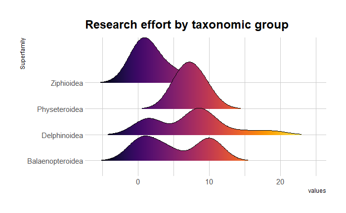

```r
#drop Dugongidae from plot
lhpnodugong<-filter(lhp, Superfamily != "Dugongidae")

ggplot(lhpnodugong,
       aes(x = values,
           y = Superfamily,
           fill = ..x..)) +
  geom_density_ridges_gradient(alpha = 0.1, rel_min_height = 0.01) +
  scale_fill_viridis(name = "Temp. [F]", option = "B") +
  labs(title="Research effort by taxonomic group") +
  theme_ipsum() +
  theme(legend.position="none",
        panel.spacing = unit(1, "lines"),
        strip.text.x = element_text(size = 1))
```

Now, let’s convert the Superfamily into a categorical variable

```r
lhp$Superfamily=as.factor(lhp$Superfamily)
levels(lhp$Superfamily)
```

```
[1] "Balaenopteroidea" "Delphinoidea"     "Dugongidae"       "Physeteroidea"    "Ziphioidea"
```

```r
lhp$Superfamily=as.factor(lhp$Superfamily)
```

### GLMM ANALYSIS

Now convert it back to numeric

```r
lhp$redlistPH=as.numeric(lhp$redlistPH)
str(lhp)
```

```
'data.frame':   30 obs. of  10 variables:
 $ Superfamily   : Factor w/ 5 levels "Balaenopteroidea",..: 3 2 2 2 2 2 2 2 2 2 ...
 $ Family        : chr  "Dugongidae" "Delphinidae" "Delphinidae" "Delphinidae" ...
 $ species       : chr  "Dugong dugon" "Feresa attenuata" "Globicephala macrorhynchus" "Grampus griseus" ...
 $ values        : int  6 7 10 9 15 8 1 9 2 11 ...
 $ ageatsex      : num  7 NA 10.5 9 6 4.5 15 14 9.5 10.5 ...
 $ maxlength     : num  3.3 2.6 6.35 3.8 2.7 2.75 9.15 2.78 5.5 2.5 ...
 $ gregariousness: num  1 3 52 8 92 4 3 143 30 84 ...
 $ habitat       : chr  "coastal" "offshore" "offshore" "offshore" ...
 $ strandings    : int  62 15 36 69 83 4 0 60 15 54 ...
 $ redlistPH     : num  2 1 1 1 2 2 1 1 1 1 ...
```

```r
head(lhp$redlistPH)
```

```
[1] 2 1 1 1 2 2
```

We need to convert redlistPH into a binary factor of 1s and 0s

```r
lhp$redlistPH[lhp$redlistPH==1]<-0
lhp$redlistPH[lhp$redlistPH==2]<-1
```

glmer using Laplace Approximation

```r
lhp.glmer<-glmer(redlistPH~values+(1|Superfamily), family=binomial, data=lhp)
```

```
boundary (singular) fit: see ?isSingular
```

```r
summary(lhp.glmer)
```

```
Generalized linear mixed model fit by maximum likelihood (Laplace Approximation) ['glmerMod']
 Family: binomial  ( logit )
Formula: redlistPH ~ values + (1 | Superfamily)
   Data: lhp

     AIC      BIC   logLik deviance df.resid
      26       30      -10       20       27

Scaled residuals:
   Min     1Q Median     3Q    Max
-0.977 -0.423 -0.149 -0.098  2.910

Random effects:
 Groups      Name        Variance Std.Dev.
 Superfamily (Intercept) 0        0
Number of obs: 30, groups:  Superfamily, 5

Fixed effects:
            Estimate Std. Error z value Pr(>|z|)
(Intercept)   -4.645      1.806   -2.57    0.010 *
values         0.418      0.198    2.11    0.035 *
---
Signif. codes:  0 ‘***’ 0.001 ‘**’ 0.01 ‘*’ 0.05 ‘.’ 0.1 ‘ ’ 1

Correlation of Fixed Effects:
       (Intr)
values -0.950
convergence code: 0
boundary (singular) fit: see ?isSingular
```

PQL in MASS package using Penalized quasi likelihood

```r
LHP.PQL<-glmmPQL(redlistPH~values, random=~1|Superfamily, data=lhp, family=binomial)
```

```
iteration 1
iteration 2
iteration 3
iteration 4
iteration 5
iteration 6
iteration 7
iteration 8
iteration 9
iteration 10
```

```r
summary(LHP.PQL)
```

```
Linear mixed-effects model fit by maximum likelihood
 Data: lhp
```

|  | AIC | BIC | logLik |
| --- | --- | --- | --- |
|  | NA | NA | NA |

```
Random effects:
 Formula: ~1 | Superfamily
        (Intercept) Residual
StdDev:        0.23     0.76

Variance function:
 Structure: fixed weights
 Formula: ~invwt
Fixed effects: redlistPH ~ values
```

|  | Value | Std.Error | DF | t-value | p-value |
| --- | --- | --- | --- | --- | --- |
| (Intercept) | -5.8 | 2.07 | 24 | -2.8 | 0.0094 |
| values | 0.5 | 0.22 | 24 | 2.4 | 0.0243 |

```
 Correlation:
       (Intr)
values -0.97

Standardized Within-Group Residuals:
   Min     Q1    Med     Q3    Max
-1.306 -0.518 -0.106 -0.063  3.983

Number of Observations: 30
Number of Groups: 5
```

Because PQL (Penalized quasi-likelihood) is the least accurate technique and suffers even more with small datasets like this one, let’s try another glmm. see below

GLMM using adaptive gausse hermite quadrature rule using GLMMadaptive package

```r
glmmadaptive<-mixed_model(redlistPH~values, random=~1|Superfamily, data=lhp, family=binomial())
summary(glmmadaptive)
```

```
Call:
mixed_model(fixed = redlistPH ~ values, random = ~1 | Superfamily,
    data = lhp, family = binomial())

Data Descriptives:
Number of Observations: 30
Number of Groups: 5

Model:
 family: binomial
 link: logit

Fit statistics:
```

|  | log.Lik | AIC | BIC |
| --- | --- | --- | --- |
|  | -10 | 26 | 25 |

```
Random effects covariance matrix:
```

|  | StdDev |
| --- | --- |
| (Intercept) | 0.45 |

```
Fixed effects:
```

|  | Estimate | Std.Err | z-value | p-value |
| --- | --- | --- | --- | --- |
| (Intercept) | -4.76 | 1.99 | -2.4 | 0.02 |
| values | 0.44 | 0.25 | 1.8 | 0.08 |

```
Integration:
method: adaptive Gauss-Hermite quadrature rule
quadrature points: 11

Optimization:
method: hybrid EM and quasi-Newton
converged: TRUE
```

# **STATS all done!!!!! Congratulations!!!!!**